# Experiment 1: Analysis

Making Predictions When Causal Models Change – The Role of Confounding

This script reproduces all results reported for Experiment 1 (Section 3.2 and the Participants section 3.1.3) and Figure 5 of the manuscript. Data: `data/exp1_data.csv` (see `CODEBOOK.md`). Figure output: `figures/`.

# Setup

```r
library(tidyverse)  # data wrangling (dplyr, tidyr) and ggplot2
library(afex)       # aov_car()
library(emmeans)    # estimated marginal means and contrasts
library(binom)      # Wilson CIs for the cluster proportions
library(Hmisc)      # mean_cl_boot() used in stat_summary()
library(ggpubr)     # ggarrange()
library(showtext)   # font rendering

# Fonts: Google fonts are downloaded at run time. Without an internet
# connection the figure falls back to the default sans font.
fonts_ok <- tryCatch({
  font_add_google("Outfit", "title_font")
  font_add_google("Cabin", "body_font")
  TRUE
}, error = function(e) FALSE)
title_font <- if (fonts_ok) "title_font" else "sans"
body_font  <- if (fonts_ok) "body_font"  else "sans"
showtext_auto()
showtext_opts(dpi = 300)

dir.create("figures", showWarnings = FALSE)
```

# Data and exclusions

Participants were excluded if they did not confirm participating via a PC or laptop, did not confirm taking the study seriously, or answered the comprehension check about the causal role of A (`A_check`) incorrectly.

```r
tdata_raw <- read.csv("data/exp1_data.csv")

tdata <- subset(tdata_raw,
                desktop_conf == "1: I confirm" &
                attent_conf  == "1: I will take it seriously" &
                A_check      == "correct")

cat("Recruited:", nrow(tdata_raw),
    "| Excluded:", nrow(tdata_raw) - nrow(tdata),
    "| Final N:", nrow(tdata), "\n")
```

```
Recruited: 259 | Excluded: 55 | Final N: 204
```

```r
# n per pair (condition)
table(tdata$comparison)
```

```
ic_cccf   sl_cc
    102     102
```

## Demographics

```r
tdata %>%
  summarise(M_age = mean(age), SD_age = sd(age),
            min_age = min(age), max_age = max(age))
```

```
     M_age   SD_age min_age max_age
1 39.16176 13.63162      19      72
```

# Normative values

Normative values of P(e|c) (Equations 2 and 4 of the manuscript), using the parameter values shown in Figure 2.

```r
# Equation 2: independent-causes model
p_ec_ic <- function(w_ce, w_ae, b_a) {
  w_ce + b_a * w_ae - w_ce * b_a * w_ae
}

# Equation 4: confounded model (generative confounding link A -> C)
p_ec_cccf <- function(w_ce, w_ae, w_ac, b_a, b_c) {
  numerator   <- w_ac * b_a + b_c * b_a - w_ac * b_c * b_a
  denominator <- w_ac * b_a + b_c - w_ac * b_c * b_a
  w_ce + (1 - w_ce) * w_ae * (numerator / denominator)
}

preds <- data.frame(
  comparison = c("Pair 1", "Pair 1", "Pair 2", "Pair 2"),
  case       = c("case 1", "case 2", "case 1", "case 2"),
  prediction = c(
    p_ec_ic(w_ce = 0.3, w_ae = 0.9, b_a = 0.2),                         # independent-causes model
    p_ec_cccf(w_ce = 0.3, w_ae = 0.9, w_ac = 0.9, b_a = 0.2, b_c = 0.2), # confounded model
    0.3,                                                                 # single-link model: P(e|c) = w_ce
    0.3                                                                  # side-effect model: P(e|c) = w_ce
  )
)
preds$comparison <- factor(preds$comparison, levels = c("Pair 1", "Pair 2"))
preds$case       <- factor(preds$case, levels = c("case 1", "case 2"))
preds
```

```
  comparison   case prediction
1     Pair 1 case 1  0.4260000
2     Pair 1 case 2  0.6369767
3     Pair 2 case 1  0.3000000
4     Pair 2 case 2  0.3000000
```

# Mean ratings

`case_1` is the rating for the first model of a pair as listed in Figure 2 (independent-causes / single-link model), `case_2` the rating for the second (confounded / side-effect model), irrespective of the side on which the model was shown.

```r
tdata_main <- tdata %>%
  select(subj_code, comparison, order, case_1, case_2) %>%
  pivot_longer(cols = c(case_1, case_2),
               names_to = "case", values_to = "rating")

tdata_main$comparison <- factor(tdata_main$comparison,
                                levels = c("ic_cccf", "sl_cc"),
                                labels = c("Pair 1", "Pair 2"))
tdata_main$case <- factor(tdata_main$case,
                          levels = c("case_1", "case_2"),
                          labels = c("case 1", "case 2"))

tdata_main$rating <- tdata_main$rating * 0.01  # convert to 0-1 scale
```

2 (Pair; between) × 2 (Model; within) ANOVA. The η²p of the interaction is the effect size reported for the interaction contrast.

```r
a1 <- aov_car(rating ~ comparison * case + Error(subj_code / case),
              tdata_main, anova_table = list(es = "pes"))
a1
```

```
Anova Table (Type 3 tests)

Response: rating
           Effect     df  MSE         F  pes p.value
1      comparison 1, 202 0.06 28.05 *** .122   <.001
2            case 1, 202 0.02 57.87 *** .223   <.001
3 comparison:case 1, 202 0.02 24.29 *** .107   <.001
---
Signif. codes:  0 '***' 0.001 '**' 0.01 '*' 0.05 '+' 0.1 ' ' 1
```

Cell means (reported as M_S1 and M_S2):

```r
emm <- emmeans(a1, ~ case * comparison)
emm
```

```
 case   comparison emmean     SE  df lower.CL upper.CL
 case.1 Pair 1      0.417 0.0172 202    0.383    0.451
 case.2 Pair 1      0.608 0.0234 202    0.561    0.654
 case.1 Pair 2      0.361 0.0172 202    0.327    0.395
 case.2 Pair 2      0.401 0.0234 202    0.355    0.448

Confidence level used: 0.95
```

Directed interaction contrast: is the increase from the first to the second model larger in Pair 1 (confounder condition) than in Pair 2 (control condition)?

```r
# cell order: (case 1, Pair 1), (case 2, Pair 1), (case 1, Pair 2), (case 2, Pair 2)
contrast(emm, list(interaction = c(-1, 1, 1, -1)), side = ">")
```

```
 contrast    estimate     SE  df t.ratio p.value
 interaction     0.15 0.0304 202   4.928  <.0001

P values are right-tailed
```

# Clusters

Participants are clustered by their intra-individual rating difference (`case_2 - case_1`). Differences within ±3 points on the 0–100 rating scale are classified as “no change”.

```r
margin_of_error <- 3  # on the 0-100 rating scale

tdata_clusters <- tdata %>%
  mutate(
    rating_difference = case_2 - case_1,
    cluster = case_when(
      abs(rating_difference) <= margin_of_error ~ "no change",
      rating_difference >  margin_of_error      ~ "increase",
      rating_difference < -margin_of_error      ~ "decrease"
    )
  )

tdata_clusters$comparison <- factor(tdata_clusters$comparison,
                                    levels = c("ic_cccf", "sl_cc"),
                                    labels = c("Pair 1", "Pair 2"))

cluster_summary <- tdata_clusters %>%
  count(comparison, cluster, name = "n") %>%
  group_by(comparison) %>%
  mutate(n_total = sum(n),
         p = n / n_total,
         percentage = 100 * p) %>%
  ungroup() %>%
  # Wilson 95% CI for each bar
  bind_cols(
    binom.confint(x = .$n, n = .$n_total, methods = "wilson") %>%
      transmute(ci_low = 100 * lower, ci_high = 100 * upper)
  )

cluster_summary
```

```
# A tibble: 6 × 8
  comparison cluster       n n_total      p percentage ci_low ci_high
  <fct>      <chr>     <int>   <int>  <dbl>      <dbl>  <dbl>   <dbl>
1 Pair 1     decrease      7     102 0.0686       6.86   3.36    13.5
2 Pair 1     increase     57     102 0.559       55.9   46.2     65.1
3 Pair 1     no change    38     102 0.373       37.3   28.5     46.9
4 Pair 2     decrease      9     102 0.0882       8.82   4.71    15.9
5 Pair 2     increase     22     102 0.216       21.6   14.7     30.5
6 Pair 2     no change    71     102 0.696       69.6   60.1     77.7
```

## Cluster differences between conditions

Directed two-sample tests for equality of proportions (with continuity correction).

```r
get_n <- function(pair, cl) {
  n <- cluster_summary$n[cluster_summary$comparison == pair &
                         cluster_summary$cluster == cl]
  if (length(n) == 0) 0 else n
}
n_pair1 <- sum(cluster_summary$n[cluster_summary$comparison == "Pair 1"])
n_pair2 <- sum(cluster_summary$n[cluster_summary$comparison == "Pair 2"])

# "increase" cluster: Pair 1 > Pair 2
prop.test(x = c(get_n("Pair 1", "increase"), get_n("Pair 2", "increase")),
          n = c(n_pair1, n_pair2),
          alternative = "greater", correct = TRUE)
```

```
    2-sample test for equality of proportions with continuity correction

data:  c(get_n("Pair 1", "increase"), get_n("Pair 2", "increase")) out of c(n_pair1, n_pair2)
X-squared = 23.881, df = 1, p-value = 5.124e-07
alternative hypothesis: greater
95 percent confidence interval:
 0.2283259 1.0000000
sample estimates:
   prop 1    prop 2
0.5588235 0.2156863
```

```r
# "no change" cluster: Pair 2 > Pair 1
prop.test(x = c(get_n("Pair 2", "no change"), get_n("Pair 1", "no change")),
          n = c(n_pair2, n_pair1),
          alternative = "greater", correct = TRUE)
```

```
    2-sample test for equality of proportions with continuity correction

data:  c(get_n("Pair 2", "no change"), get_n("Pair 1", "no change")) out of c(n_pair2, n_pair1)
X-squared = 20.173, df = 1, p-value = 3.536e-06
alternative hypothesis: greater
95 percent confidence interval:
 0.2050434 1.0000000
sample estimates:
   prop 1    prop 2
0.6960784 0.3725490
```

## Is the normative cluster an absolute majority?

Directed one-sample proportion tests against 0.5 (with continuity correction). Normative clusters: “increase” in Pair 1, “no change” in Pair 2.

```r
prop.test(x = get_n("Pair 1", "increase"), n = n_pair1,
          p = 0.50, alternative = "greater", correct = TRUE)
```

```
    1-sample proportions test with continuity correction

data:  get_n("Pair 1", "increase") out of n_pair1, null probability 0.5
X-squared = 1.1863, df = 1, p-value = 0.138
alternative hypothesis: true p is greater than 0.5
95 percent confidence interval:
 0.4726114 1.0000000
sample estimates:
        p
0.5588235
```

```r
prop.test(x = get_n("Pair 2", "no change"), n = n_pair2,
          p = 0.50, alternative = "greater", correct = TRUE)
```

```
    1-sample proportions test with continuity correction

data:  get_n("Pair 2", "no change") out of n_pair2, null probability 0.5
X-squared = 14.912, df = 1, p-value = 5.633e-05
alternative hypothesis: true p is greater than 0.5
95 percent confidence interval:
 0.6118061 1.0000000
sample estimates:
        p
0.6960784
```

# Figure 5

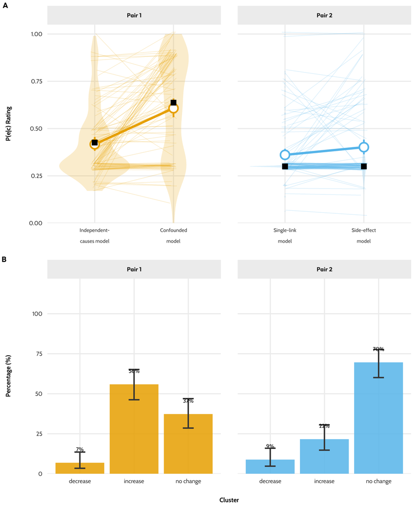

```r
set.seed(1)  # bootstrapped CIs and jittered individual lines

pub_palette <- c("#E69F00", "#56B4E9", "#009E73",
                 "#F0E442", "#0072B2", "#D55E00", "#CC79A7")

# --- ONE knob: all text scales from BASE -------------------------
BASE <- 14
LAB  <- BASE + 4    # panel letters A / B
TXT  <- BASE - 1    # in-plot percentage labels

theme_pub <- function(base = BASE) {
  theme_minimal(base_size = base) +
    theme(
      text             = element_text(family = body_font),
      strip.background = element_rect(fill = "grey92", color = "grey92"),
      strip.text       = element_text(face = "bold", size = base,
                                      family = title_font,
                                      margin = margin(5, 5, 5, 5)),
      axis.title       = element_text(face = "bold", size = base + 1),
      axis.title.x     = element_text(margin = margin(t = 10), face = "bold"),
      axis.title.y     = element_text(margin = margin(r = 10), face = "bold"),
      axis.text        = element_text(size = base, color = "grey20"),
      panel.grid.minor = element_blank(),
      legend.position  = "none"
    )
}

# --- Per-facet x labels -----------------------------------------
make_case_label <- function(d) {
  d$case_label <- factor(
    paste(d$comparison, d$case),
    levels = c("Pair 1 case 1", "Pair 1 case 2",
               "Pair 2 case 1", "Pair 2 case 2"),
    labels = c("Independent-\ncauses model", "Confounded\nmodel",
               "Single-link\nmodel",         "Side-effect\nmodel")
  )
  d
}

tdata_sub  <- make_case_label(tdata_main)
preds_plot <- make_case_label(preds)

# --- Panel A: ratings --------------------------------------------
g3 <- ggplot(tdata_sub, aes(x = case_label, y = rating,
                            fill = comparison, color = comparison)) +
  facet_wrap(~ comparison, nrow = 1, scales = "free_x") +
  geom_line(aes(group = subj_code),
            position = position_jitter(height = 0.02, width = 0.05),
            linewidth = 0.35, alpha = 0.2) +
  geom_violin(alpha = 0.2, color = NA, trim = TRUE) +
  stat_summary(aes(group = 1), fun.data = mean_cl_boot, geom = "errorbar",
               width = 0, linewidth = 1) +
  stat_summary(aes(group = 1), fun = mean, geom = "line", linewidth = 1.3) +
  stat_summary(aes(group = 1), fun = mean, geom = "point", shape = 21,
               size = 4.2, stroke = 1.4, fill = "white") +
  geom_point(data = preds_plot, aes(x = case_label, y = prediction),
             color = "black", fill = "black", size = 3, shape = 22) +
  scale_y_continuous(limits = c(0, 1.05), breaks = seq(0, 1, 0.25),
                     expand = c(0, 0)) +
  scale_color_manual(values = pub_palette) +
  scale_fill_manual(values = pub_palette) +
  labs(x = NULL, y = "P(e|c) Rating") +
  theme_pub() +
  theme(panel.spacing = unit(1.4, "lines"),
        axis.text.x   = element_text(size = BASE - 2, lineheight = 0.9))

# --- Panel B: clusters -------------------------------------------
g4 <- ggplot(cluster_summary, aes(x = cluster, y = percentage,
                                  fill = comparison)) +
  facet_wrap(~ comparison, nrow = 1) +
  geom_bar(stat = "identity", alpha = 0.85, color = NA) +
  geom_errorbar(aes(ymin = ci_low, ymax = ci_high), width = 0.2,
                linewidth = 0.8, color = "grey20") +
  geom_text(aes(label = paste0(round(percentage, 0), "%")),
            vjust = -3, family = body_font, size = TXT / .pt) +
  scale_y_continuous(limits = c(0, 122), breaks = seq(0, 100, 25),
                     expand = c(0, 0)) +
  scale_fill_manual(values = pub_palette) +
  labs(x = "Cluster", y = "Percentage (%)") +
  theme_pub() +
  theme(panel.spacing = unit(1.4, "lines"))

# --- Assemble ----------------------------------------------------
figure5 <- ggarrange(g3, g4,
                     labels = c("A", "B"),
                     font.label = list(size = LAB, color = "black",
                                       family = title_font),
                     ncol = 1, nrow = 2, align = "v")
figure5
```

```r
ggsave("figures/Figure5_Exp1.pdf", figure5,
       width = 6.9, height = 8.4, units = "in", device = cairo_pdf)
```